# Logistic Reg - Keras - for portfolio

## Classification using neural networks

Here we'll create a model capable of predicting whether a customer will churn using labeled data from a fictious telecommunications company.

```python
#Import libraries
import numpy as np
import pandas as pd
import matplotlib.pyplot as plt
from sklearn.preprocessing import StandardScaler
from tensorflow.keras.layers import Input, Dense, Dropout
from tensorflow.keras.models import Sequential
from keras.optimizers import Adam
from keras.callbacks import EarlyStopping
from sklearn import model_selection
```

```python
#Read in data
data= pd.read_csv('churn_clean.csv')
```

The data consists of 50 variables. We'll select specific variables that may have an impact on churn.

```python
#Select variables of interest
data = data[['Income', 'Churn', 'Outage_sec_perweek', 'Email', 'Contacts', 'Yearly_equip_failure', 'Techie',
             'Contract', 'StreamingTV', 'StreamingMovies', 'Tenure', 'MonthlyCharge']]
```

There are 10000 observations in the data set. There are 12 varialbes total. Churn will be the target variable; the rest will be the predictors.

```python
data.shape
```

```
(10000, 12)
```

The variables of type 'object' are categorical. They are originally represented using strings. They'll need to be converted into dummy variables.

```python
data.info()
```

```
<class 'pandas.core.frame.DataFrame'>
RangeIndex: 10000 entries, 0 to 9999
Data columns (total 12 columns):
 #   Column                Non-Null Count  Dtype
---  ------                --------------  -----
 0   Income                10000 non-null  float64
 1   Churn                 10000 non-null  object
 2   Outage_sec_perweek    10000 non-null  float64
 3   Email                 10000 non-null  int64
 4   Contacts              10000 non-null  int64
 5   Yearly_equip_failure  10000 non-null  int64
 6   Techie                10000 non-null  object
 7   Contract              10000 non-null  object
 8   StreamingTV           10000 non-null  object
 9   StreamingMovies       10000 non-null  object
 10  Tenure                10000 non-null  float64
 11  MonthlyCharge         10000 non-null  float64
dtypes: float64(4), int64(3), object(5)
memory usage: 937.6+ KB
```

Most of the categorical variables are in the form 'yes' or 'no'. We can simply replace that with 1 or 0.

```python
#Manually do dummy variables for yes/no varialbes
data['Churn'] = data['Churn'].replace({'Yes':1, 'No':0})
data['Techie'] = data['Techie'].replace({'Yes':1, 'No':0})
data['StreamingTV'] = data['StreamingTV'].replace({'Yes':1, 'No':0})
data['StreamingMovies'] = data['StreamingMovies'].replace({'Yes':1, 'No':0})
```

The Contract variable has 3 values

```python
pd.unique(data.Contract)
```

```
array(['One year', 'Month-to-month', 'Two Year'], dtype=object)
```

We'll convert Contract to a dummy variable using Panda's get_dummies function.

```python
#Get dummies for Contract (has 3 levels)
data = pd.get_dummies(data, columns=['Contract'], dtype=int)
```

We'll scale the continuous variables before modeling.

```python
#Scale the numeric variables
scaler = StandardScaler()
data[['Income', 'Outage_sec_perweek', 'Email', 'Contacts', 'Yearly_equip_failure', 'Tenure', 'MonthlyCharge']] = \
    scaler.fit_transform(
        data[['Income', 'Outage_sec_perweek', 'Email', 'Contacts', 'Yearly_equip_failure', 'Tenure', 'MonthlyCharge']])
```

All variables are numeric now.

```python
data.head()
```

|  | Income | Churn | Outage_sec_perweek | Email | Contacts | Yearly_equip_failure | Techie | StreamingTV | StreamingMovies | Tenure | MonthlyCharge | Contract_Month-to-month | Contract_One year | Contract_Two Year |
| --- | --- | --- | --- | --- | --- | --- | --- | --- | --- | --- | --- | --- | --- | --- |
| 0 | -0.398778 | 0 | -0.679978 | -0.666282 | -1.005852 | 0.946658 | 0 | 0 | 1 | -1.048746 | -0.003943 | 0 | 1 | 0 |
| 1 | -0.641954 | 1 | 0.570331 | -0.005288 | -1.005852 | 0.946658 | 1 | 1 | 1 | -1.262001 | 1.630326 | 1 | 0 | 0 |
| 2 | -1.070885 | 0 | 0.252347 | -0.996779 | -1.005852 | 0.946658 | 1 | 0 | 1 | -0.709940 | -0.295225 | 0 | 0 | 1 |
| 3 | -0.740525 | 0 | 1.650506 | 0.986203 | 1.017588 | -0.625864 | 1 | 1 | 0 | -0.659524 | -1.226521 | 0 | 0 | 1 |
| 4 | 0.009478 | 1 | -0.623156 | 1.316700 | 1.017588 | 0.946658 | 0 | 1 | 0 | -1.242551 | -0.528086 | 1 | 0 | 0 |

Creating dummies for Contract resulted the variable being represented with 3 columns instead of 1.

```python
data.shape
```

```
(10000, 14)
```

We'll remove Churn to create the group of predictors.

```python
predictors = data.drop('Churn', axis= 1)
```

```python
predictors.shape
```

```
(10000, 13)
```

We'll isolate Churn as the target variable.

```python
target = data['Churn']
```

```python
target.shape
```

```
(10000,)
```

We'll split the data into training and test sets using a 80/20 ratio.

```python
X_train, X_test, y_train, y_test= \
model_selection.train_test_split(predictors, target, random_state= 42, test_size= 0.20)
```

Now we're ready to create the model using the Keras interface to TensorFlow.

```python
# Set up the model
model = Sequential()
model.add(Input(shape= (predictors.shape[1], )))
model.add(Dense(500, activation= 'relu'))
model.add(Dense(1, activation= 'sigmoid'))

# Compile the model
model.compile(loss= 'binary_crossentropy', optimizer= Adam(learning_rate= 0.0001), metrics= ['accuracy'])

#View model summary
model.summary()
```

```
Model: "sequential_1"
```

```
┏━━━━━━━━━━━━━━━━━━━━━━━━━━━━━━━━━━━━━━┳━━━━━━━━━━━━━━━━━━━━━━━━━━━━━┳━━━━━━━━━━━━━━━━━┓
┃ Layer (type)                         ┃ Output Shape                ┃         Param # ┃
┡━━━━━━━━━━━━━━━━━━━━━━━━━━━━━━━━━━━━━━╇━━━━━━━━━━━━━━━━━━━━━━━━━━━━━╇━━━━━━━━━━━━━━━━━┩
│ dense_2 (Dense)                      │ (None, 500)                 │           7,000 │
├──────────────────────────────────────┼─────────────────────────────┼─────────────────┤
│ dense_3 (Dense)                      │ (None, 1)                   │             501 │
└──────────────────────────────────────┴─────────────────────────────┴─────────────────┘
```

```
 Total params: 7,501 (29.30 KB)
```

```
 Trainable params: 7,501 (29.30 KB)
```

```
 Non-trainable params: 0 (0.00 B)
```

We set up and early stopping monitor which will help prevent overfitting.

```python
early_stopping= EarlyStopping(patience= 2)
```

And now fit the model on the training data using the test data for valildation.

```python
# Fit the model
history = model.fit(X_train, y_train, epochs= 20, validation_data= (X_test, y_test), callbacks= [early_stopping])
```

```
250/250 ━━━━━━━━━━━━━━━━━━━━ 1s 2ms/step - accuracy: 0.6815 - loss: 0.6182 - val_accuracy: 0.8005 - val_loss: 0.4587
250/250 ━━━━━━━━━━━━━━━━━━━━ 0s 1ms/step - accuracy: 0.8334 - loss: 0.4192 - val_accuracy: 0.8610 - val_loss: 0.3554
250/250 ━━━━━━━━━━━━━━━━━━━━ 0s 2ms/step - accuracy: 0.8630 - loss: 0.3345 - val_accuracy: 0.8785 - val_loss: 0.3066
250/250 ━━━━━━━━━━━━━━━━━━━━ 0s 1ms/step - accuracy: 0.8716 - loss: 0.2970 - val_accuracy: 0.8845 - val_loss: 0.2852
250/250 ━━━━━━━━━━━━━━━━━━━━ 0s 2ms/step - accuracy: 0.8725 - loss: 0.2831 - val_accuracy: 0.8890 - val_loss: 0.2751
250/250 ━━━━━━━━━━━━━━━━━━━━ 0s 1ms/step - accuracy: 0.8766 - loss: 0.2699 - val_accuracy: 0.8890 - val_loss: 0.2703
250/250 ━━━━━━━━━━━━━━━━━━━━ 0s 2ms/step - accuracy: 0.8816 - loss: 0.2622 - val_accuracy: 0.8900 - val_loss: 0.2677
250/250 ━━━━━━━━━━━━━━━━━━━━ 0s 1ms/step - accuracy: 0.8849 - loss: 0.2574 - val_accuracy: 0.8895 - val_loss: 0.2670
250/250 ━━━━━━━━━━━━━━━━━━━━ 0s 1ms/step - accuracy: 0.8854 - loss: 0.2549 - val_accuracy: 0.8900 - val_loss: 0.2660
250/250 ━━━━━━━━━━━━━━━━━━━━ 0s 1ms/step - accuracy: 0.8862 - loss: 0.2503 - val_accuracy: 0.8920 - val_loss: 0.2647
250/250 ━━━━━━━━━━━━━━━━━━━━ 0s 2ms/step - accuracy: 0.8881 - loss: 0.2482 - val_accuracy: 0.8930 - val_loss: 0.2643
250/250 ━━━━━━━━━━━━━━━━━━━━ 0s 1ms/step - accuracy: 0.8894 - loss: 0.2482 - val_accuracy: 0.8925 - val_loss: 0.2634
250/250 ━━━━━━━━━━━━━━━━━━━━ 0s 2ms/step - accuracy: 0.8890 - loss: 0.2498 - val_accuracy: 0.8925 - val_loss: 0.2636
250/250 ━━━━━━━━━━━━━━━━━━━━ 0s 2ms/step - accuracy: 0.8928 - loss: 0.2469 - val_accuracy: 0.8925 - val_loss: 0.2634
```

The early stopping monitor stopped the process after 14 epoch since the validation loss wasn't improving.

Next we can visualize model performance

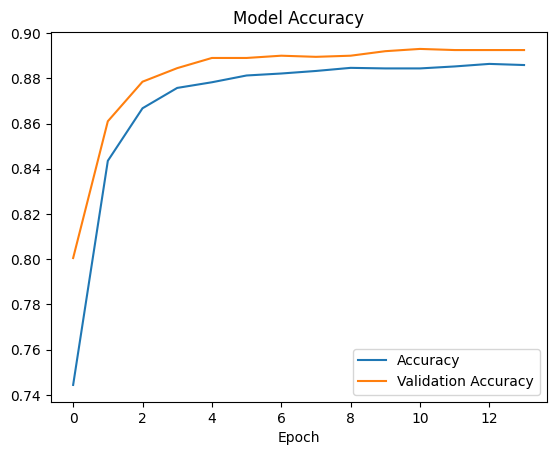

```python
plt.plot(history.history['accuracy'], label='Accuracy')
plt.plot(history.history['val_accuracy'], label='Validation Accuracy')
plt.title("Model Accuracy")
plt.xlabel("Epoch")
plt.legend()
plt.show()
```

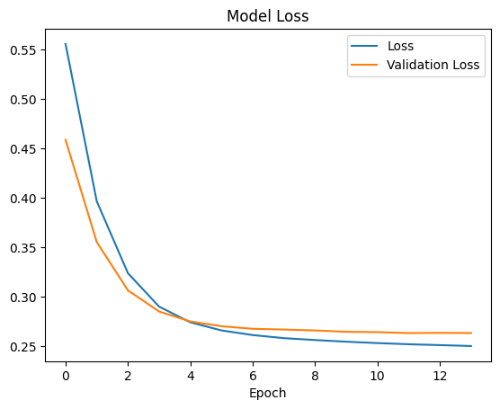

```python
plt.plot(history.history['loss'], label='Loss')
plt.plot(history.history['val_loss'], label='Validation Loss')
plt.title("Model Loss")
plt.xlabel("Epoch")
plt.legend()
plt.show()
```

And finally evaluate the model on the test data.

```python
model.evaluate(X_test, y_test)
```

```
63/63 ━━━━━━━━━━━━━━━━━━━━ 0s 702us/step - accuracy: 0.8850 - loss: 0.2732
```

```
[0.26341530680656433, 0.8924999833106995]
```

The model achieves an accuracy of 89% meaning it can correclty predict wether or not a customer will churn 89% of the time.